# The Rise of the 3 Pointer

Since its introduction to the NBA, the 3 pointer has gradually grown more popular, as players have become more accurate

The volume of shots has also grown steadily, especially in recent years

But wait - what about this sharp increase and decrease in shots attempted between the 1994 and 1996 seasons?

In the beginnning of the 1994 season, the arc was shortened from 23 ft and 9 inches and 22 feet in the corners to 22 feet all around. This made the 3 pointer an overall slightly easier shot to make, driving up shot volume. However, beginning in the 1997 season, they reverted the 3 point line as while 3 point volume increased, overall scoring decreased ~5 points per game.

Lets go back now and see if there are any other trends

Right after 2010, the volume in 3 pointers rose sharply.

Zooming in, we can see the sharp increase in 3 point volume across the league

While the volume of 3 pointers shot has increased steadily since its inception, what might have caused this sharp increase in volume? Over the span of a decade, the average 3 point attempts doubled from 17 shots/game to almost 35.

Lets go back to the 3pt attempts

One team in particular, the golden state warriors shoots significantly more shots than the rest

These are the years they won the championship, denoted by the trophy icon

The increase in volume and elite shooting accuracy are one of the key reasons they have won multiple championships in the past 15 years. Additionally, lead by 2 goat shooters, steph and klay.

But why do 3 pointers and shooting more of them contribute to winning?

As basketball players have become more accurate, the 3 point shot has gradually become more valuable per shot

Sources: https://hoopstudent.com/basketball-defense/ https://www.basketball-reference.com/

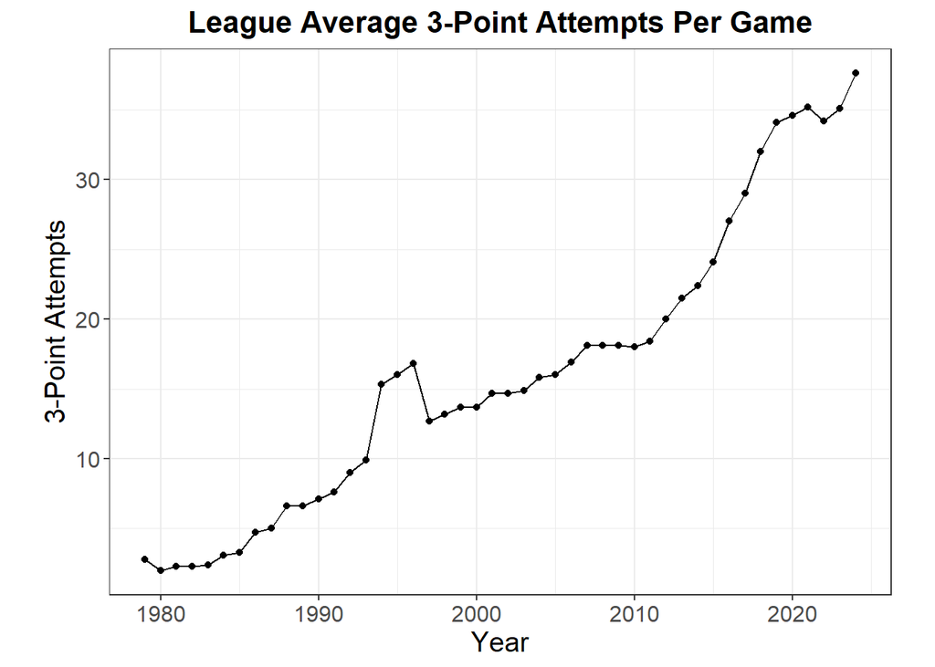

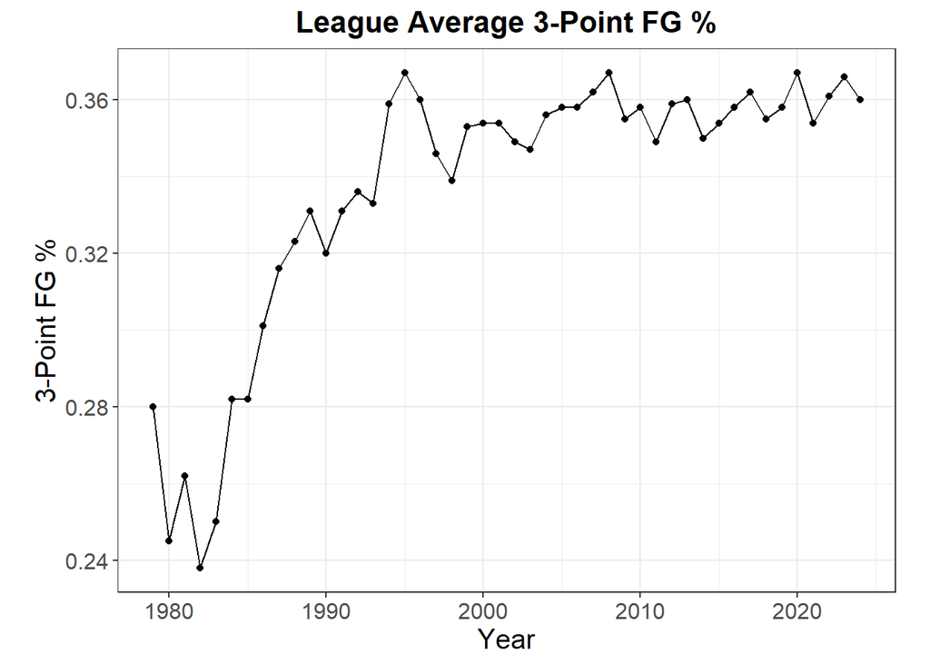

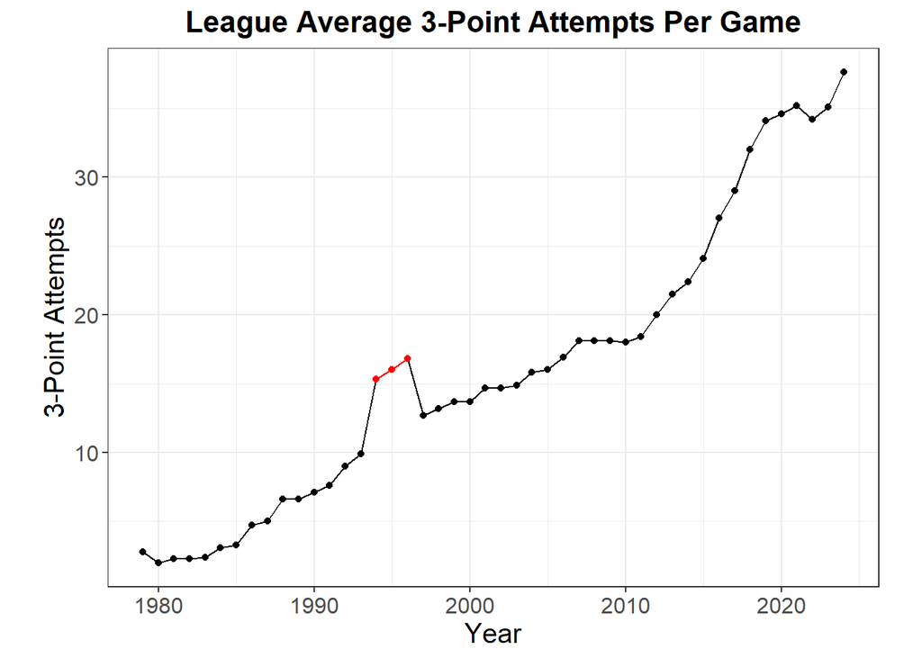

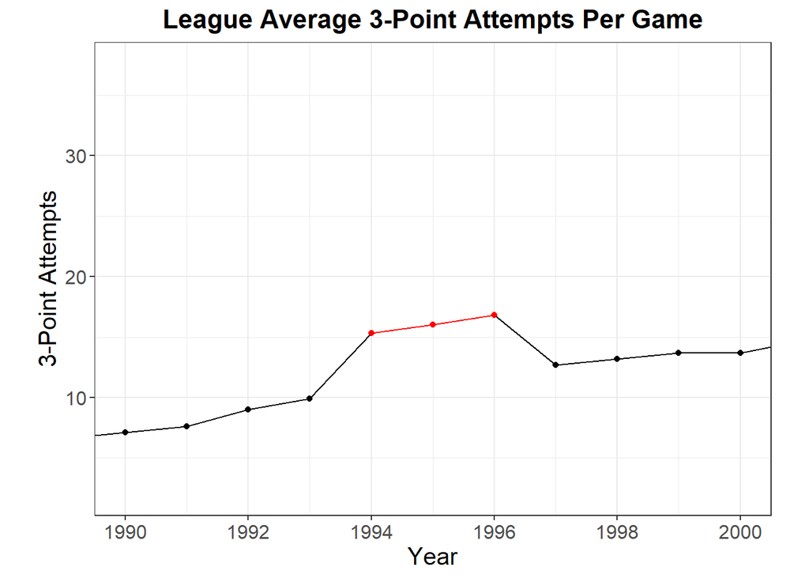

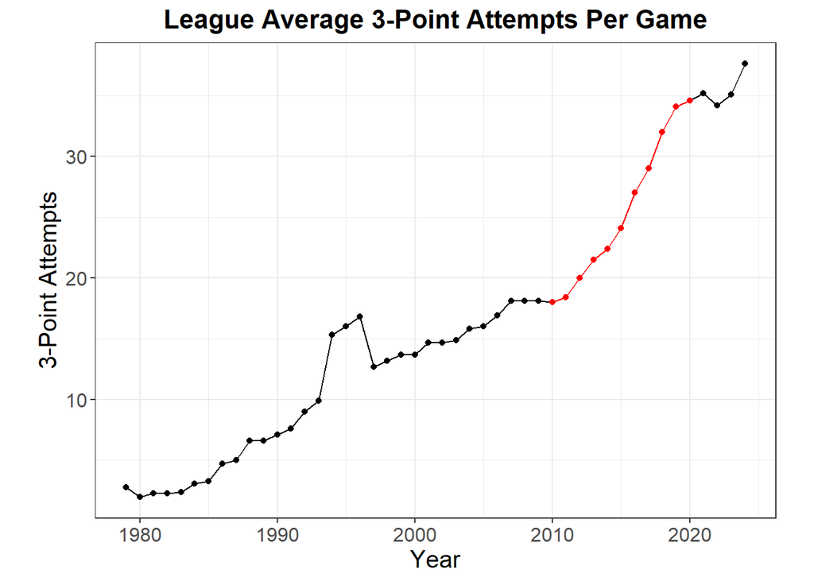

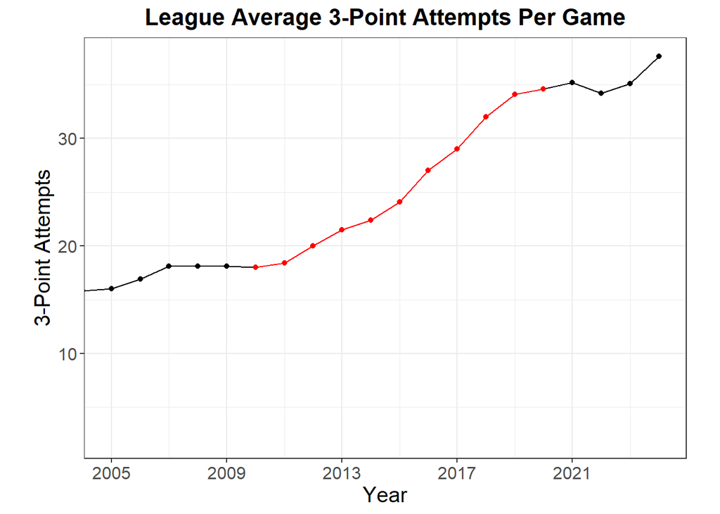

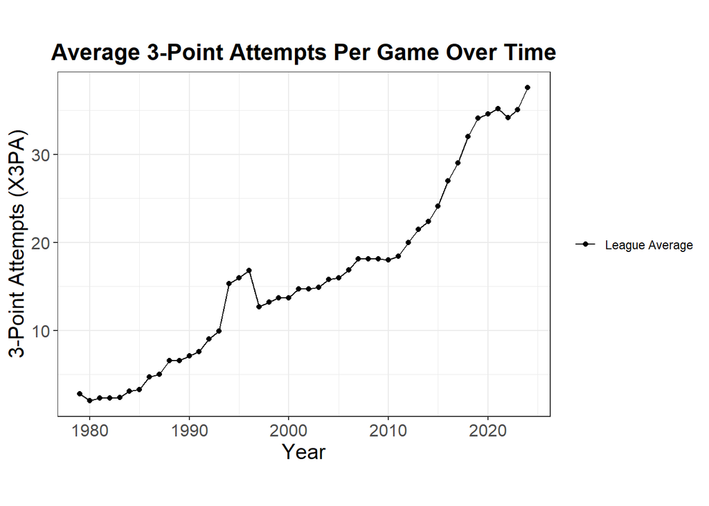

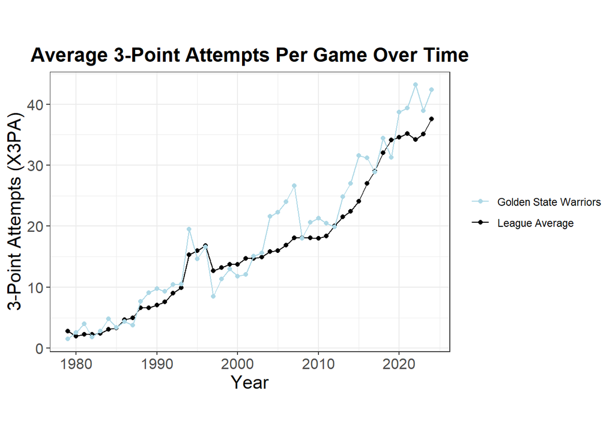

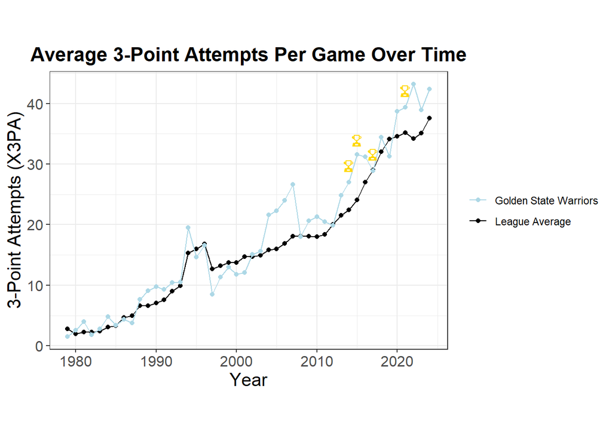

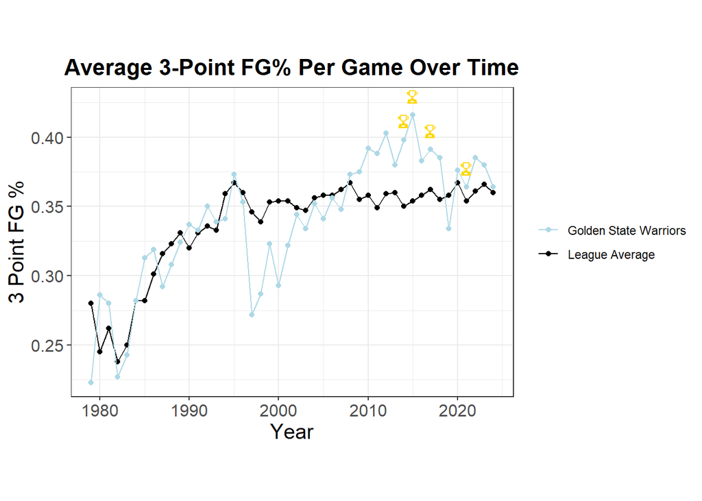

Expected points per shot is calculated from FG% x Point Value (ex: 0.36 * 3)

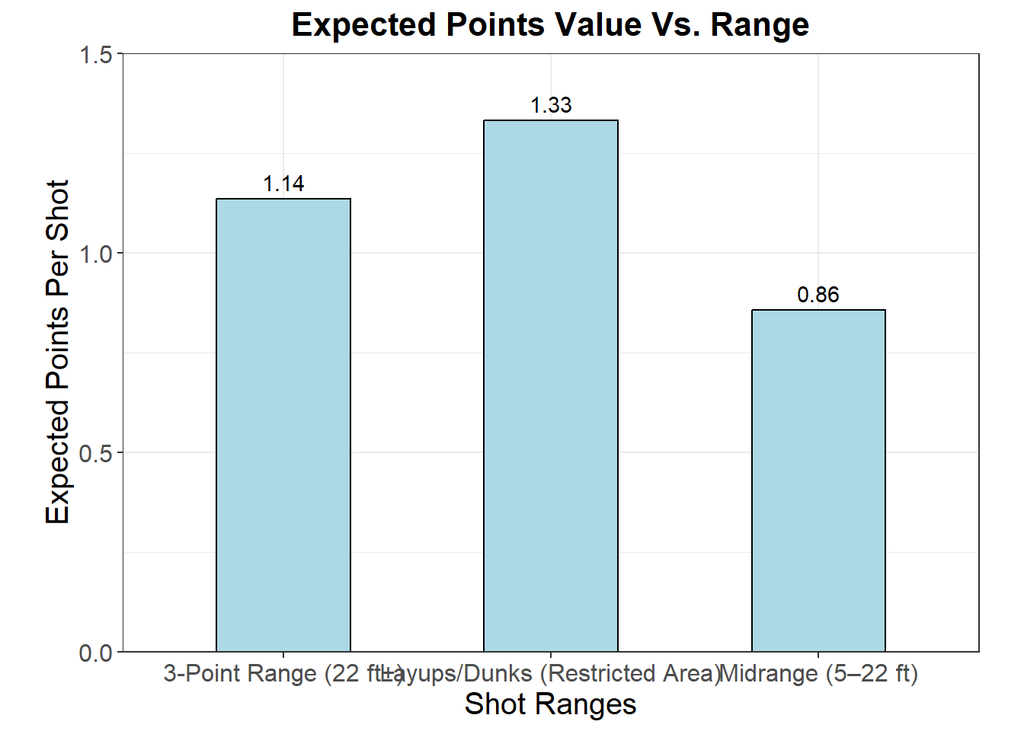

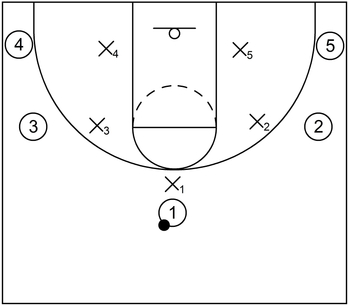